# Pima_diabetes

# Check the glucose levels in the non diabetes females to see above findings are correct. Lets check percentage of females with outcome=0 in each glucose level and confirm our findings above.

```python
# produce count of females with no diabeties in each levels and also, overall
#count of females in each levels

glucosedata_nd = glucose_data[glucose_data["Outcome"]==0].groupby("GlucoseLevels")[["Outcome"]].count()
glucosedata.head(10)
glucosedataAll = glucose_data.groupby("GlucoseLevels")[["Outcome"]].count()

# Use above two values and calulate the percentage females with diabetes in
#each Glucose levels to see the trend

glucosedata_nd["% Diabetic"] = (glucosedata_nd["Outcome"]/glucosedataAll["Outcome"])*100
glucosedata_nd.head(10)
```

| GlucoseLevels | Outcome | % Diabetic |
| --- | --- | --- |
| (44.0, 54.0] | 0 | NaN |
| (54.0, 64.0] | 4 | 100.000000 |
| (64.0, 74.0] | 15 | 100.000000 |
| (74.0, 84.0] | 41 | 93.181818 |
| (84.0, 94.0] | 64 | 94.117647 |
| (94.0, 104.0] | 79 | 81.443299 |
| (104.0, 114.0] | 81 | 76.415094 |
| (114.0, 124.0] | 63 | 68.478261 |
| (124.0, 134.0] | 42 | 56.756757 |
| (134.0, 144.0] | 32 | 58.181818 |

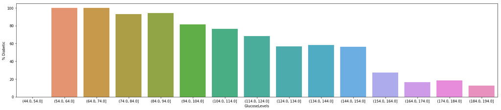

```python
#Plot above GlucoseLevels using bar chart to see the percentage of females with
#no diabetes in each GlucoseLevel

plt.figure(figsize=(25,5))
sns.barplot(x=glucosedata_nd.index, y=glucosedata_nd["% Diabetic"])
```

Above graph confirms that females with no diabetes are having low glucose levels. This confirms our findings above i.e higher the chances of getting diabetes with high glucose levels.

```python
# Analyse BMI Vs Outcome

BMI_data = Pima_diabetes4[Pima_diabetes4["BMI"]!=0]

#Use numpy,Pandas functions below to do the binning,

BMI_bins = np.arange(min(BMI_data["BMI"]),max(BMI_data["BMI"]),6)
BMI_bins

# Use bins created above and Assign BMI levels for each record in the
#dataframe

BMI_data["BMILevels"] = pd.cut(BMI_data["BMI"], bins=BMI_bins)
BMI_data.head()
```

|  | index | Pregnancies | Glucose | BloodPressure | SkinThickness | Insulin | BMI | DiabetesPedigreeFunction | Age | Outcome | Ages | BMILevels |
| --- | --- | --- | --- | --- | --- | --- | --- | --- | --- | --- | --- | --- |
| 0 | 0 | 6 | 148.0 | 72.0 | 35.0 | 80.666667 | 33.6 | 0.627 | 50 | 1 | 46-50 | (30.2, 36.2] |
| 1 | 1 | 1 | 85.0 | 66.0 | 29.0 | 80.666667 | 26.6 | 0.351 | 31 | 0 | 31-35 | (24.2, 30.2] |
| 2 | 2 | 8 | 183.0 | 64.0 | 23.0 | 80.666667 | 23.3 | 0.672 | 32 | 1 | 31-35 | (18.2, 24.2] |
| 3 | 3 | 1 | 89.0 | 66.0 | 23.0 | 94.000000 | 28.1 | 0.167 | 21 | 0 | 20-25 | (24.2, 30.2] |
| 4 | 4 | 0 | 137.0 | 40.0 | 35.0 | 168.000000 | 43.1 | 2.288 | 33 | 1 | 31-35 | (42.2, 48.2] |

```python
# produce count of females with diabeties in each levels and also, overall
#count of females in each levels

BMIdata = BMI_data[BMI_data["Outcome"]==1].groupby("BMILevels")[["Outcome"]].count()
BMIdata.head(10)
BMIdataAll = BMI_data.groupby("BMILevels")[["Outcome"]].count()
```

```python
# Use above two values and calulate the percentage females with diabetes in
#each Glucose levels to see the trend

BMIdata["% Diabetic"] = (BMIdata["Outcome"]/BMIdataAll["Outcome"])*100
BMIdata.head(10)
```

| BMILevels | Outcome | % Diabetic |
| --- | --- | --- |
| (18.2, 24.2] | 5 | 6.493506 |
| (24.2, 30.2] | 48 | 22.966507 |
| (30.2, 36.2] | 111 | 43.529412 |
| (36.2, 42.2] | 47 | 42.342342 |
| (42.2, 48.2] | 28 | 57.142857 |

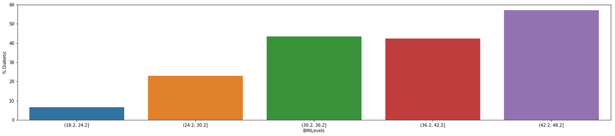

```python
#Plot above BMILevels using bar chart to see the percentage of females with
#diabetes in each BMILevel

plt.figure(figsize=(25,5))
sns.barplot(x=BMIdata.index, y=BMIdata["% Diabetic"])
```

```
(0, 70)
```

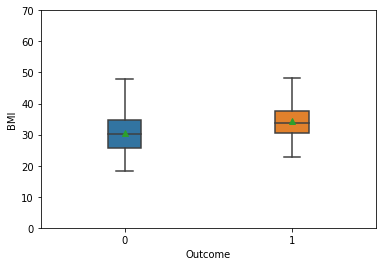

```python
#Plot Boxplot of BMI Vs Outcome

sns.boxplot(y=Pima_diabetes4.BMI,x=Pima_diabetes4.Outcome,orient="v",width=0.2,showmeans=True)
axes = plt.gca()
axes.set_ylim([0,70])
```

Above boxplots shows females with diabetes are having higher BMI compared to females with no diabetes. Average value of a female suffering from the disease has mean BMI value as 35.14.Which means that they are not healthy and obese. It is also interesting to note that the mean BMI value for the people who are not suffering from the disease is 30 which is the threshold value of people becoming obese.Hence we can say that higher the chances of getting diabetes with high BMI.

```python
# Analyse BloodPressure Vs Outcome

BP_data = Pima_diabetes4[Pima_diabetes4["BloodPressure"]!=0]

#Use numpy,Pandas functions below to do the binning,

BP_bins = np.arange(min(BP_data["BloodPressure"]),max(BP_data["BloodPressure"]),10)
BP_bins

# Use bins created above and Assign BMI levels for each record in the
#dataframe

BP_data["BPLevels"] = pd.cut(BP_data["BloodPressure"], bins=BP_bins)
BP_data.head()
```

|  | index | Pregnancies | Glucose | BloodPressure | SkinThickness | Insulin | BMI | DiabetesPedigreeFunction | Age | Outcome | Ages | BPLevels |
| --- | --- | --- | --- | --- | --- | --- | --- | --- | --- | --- | --- | --- |
| 0 | 0 | 6 | 148.0 | 72.0 | 35.0 | 80.666667 | 33.6 | 0.627 | 50 | 1 | 46-50 | (70.0, 80.0] |
| 1 | 1 | 1 | 85.0 | 66.0 | 29.0 | 80.666667 | 26.6 | 0.351 | 31 | 0 | 31-35 | (60.0, 70.0] |
| 2 | 2 | 8 | 183.0 | 64.0 | 23.0 | 80.666667 | 23.3 | 0.672 | 32 | 1 | 31-35 | (60.0, 70.0] |
| 3 | 3 | 1 | 89.0 | 66.0 | 23.0 | 94.000000 | 28.1 | 0.167 | 21 | 0 | 20-25 | (60.0, 70.0] |
| 4 | 4 | 0 | 137.0 | 40.0 | 35.0 | 168.000000 | 43.1 | 2.288 | 33 | 1 | 31-35 | NaN |

```python
# produce count of females with diabeties in each levels and also, overall
#count of females in each levels

BPdata = BP_data[BP_data["Outcome"]==1].groupby("BPLevels")[["Outcome"]].count()
BPdata.head(10)
BPdataAll = BP_data.groupby("BPLevels")[["Outcome"]].count()
```

```python
# Use above two values and calulate the percentage females with diabetes in
#each BP levels to see the trend

BPdata["% Diabetic"] = (BPdata["Outcome"]/BPdataAll["Outcome"])*100
BPdata.head(10)
```

| BPLevels | Outcome | % Diabetic |
| --- | --- | --- |
| (40.0, 50.0] | 6 | 26.086957 |
| (50.0, 60.0] | 15 | 16.483516 |
| (60.0, 70.0] | 66 | 31.578947 |
| (70.0, 80.0] | 91 | 36.991870 |
| (80.0, 90.0] | 51 | 45.535714 |
| (90.0, 100.0] | 7 | 35.000000 |

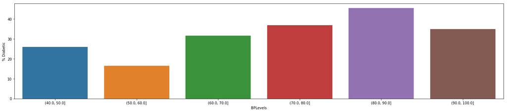

```python
#Plot above BPLevels using bar chart to see the percentage of females with
#diabetes in each BPLevel

plt.figure(figsize=(25,5))
sns.barplot(x=BPdata.index, y=BPdata["% Diabetic"])
```

There seems to be some females with very less blood pressure and few are above the threshold value 80.

```python
# Analyse PregnanciesNumber  Vs Outcome

Preg_data = Pima_diabetes4.copy()

#Use numpy,Pandas functions below to do the binning,

Preg_bins = np.arange(min(Preg_data["Pregnancies"]),max(Preg_data["Pregnancies"]),4)
Preg_bins

# Use bins created above and Assign Pregnancy levels for each record in the
#dataframe

Preg_data["PregLevels"] = pd.cut(Preg_data["Pregnancies"], bins=Preg_bins,include_lowest=True)
Preg_data.head()
```

|  | index | Pregnancies | Glucose | BloodPressure | SkinThickness | Insulin | BMI | DiabetesPedigreeFunction | Age | Outcome | Ages | PregLevels |
| --- | --- | --- | --- | --- | --- | --- | --- | --- | --- | --- | --- | --- |
| 0 | 0 | 6 | 148.0 | 72.0 | 35.0 | 80.666667 | 33.6 | 0.627 | 50 | 1 | 46-50 | (4.0, 8.0] |
| 1 | 1 | 1 | 85.0 | 66.0 | 29.0 | 80.666667 | 26.6 | 0.351 | 31 | 0 | 31-35 | (-0.001, 4.0] |
| 2 | 2 | 8 | 183.0 | 64.0 | 23.0 | 80.666667 | 23.3 | 0.672 | 32 | 1 | 31-35 | (4.0, 8.0] |
| 3 | 3 | 1 | 89.0 | 66.0 | 23.0 | 94.000000 | 28.1 | 0.167 | 21 | 0 | 20-25 | (-0.001, 4.0] |
| 4 | 4 | 0 | 137.0 | 40.0 | 35.0 | 168.000000 | 43.1 | 2.288 | 33 | 1 | 31-35 | (-0.001, 4.0] |

```python
# produce count of females with diabeties in each levels and also, overall
#count of females in each levels

Pregdata = Preg_data[Preg_data["Outcome"]==1].groupby("PregLevels")[["Outcome"]].count()
Pregdata.head(10)
PregdataAll = Preg_data.groupby("PregLevels")[["Outcome"]].count()
Pregdata.head(10)
```

| PregLevels | Outcome |
| --- | --- |
| (-0.001, 4.0] | 119 |
| (4.0, 8.0] | 79 |
| (8.0, 12.0] | 34 |
| (12.0, 16.0] | 7 |

```python
# Use above two values and calulate the percentage females with diabetes in
#each BP levels to see the trend

Pregdata["% Diabetic"] = (Pregdata["Outcome"]/PregdataAll["Outcome"])*100
Pregdata.head(10)
```

| PregLevels | Outcome | % Diabetic |
| --- | --- | --- |
| (-0.001, 4.0] | 119 | 26.385809 |
| (4.0, 8.0] | 79 | 44.134078 |
| (8.0, 12.0] | 34 | 53.968254 |
| (12.0, 16.0] | 7 | 63.636364 |

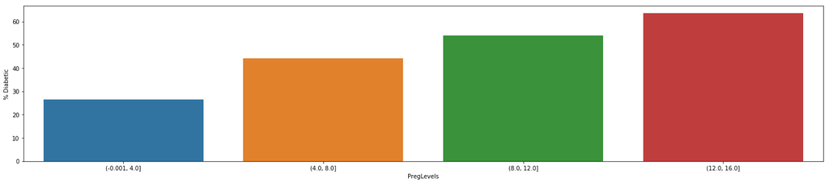

```python
#Plot above Pregancy Levels using bar chart to see the percentage of females with
#diabetes in each Preg Level

plt.figure(figsize=(25,5))
sns.barplot(x=Pregdata.index, y=Pregdata["% Diabetic"])
```

Above graph shows that percentage of diabetes is more in females with more number of pregnancies i.e 4 and above.In the next graph, look at the BMI of these females to understand more.

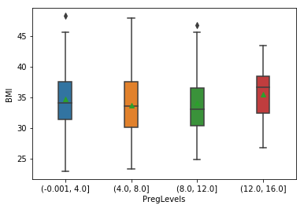

```python
#Plot Preganancy Levels with BMI

temp =Preg_data[Preg_data["Outcome"]==1]
sns.boxplot(y=temp.BMI,x=temp.PregLevels,orient="v",width=0.2,showmeans=True)
```

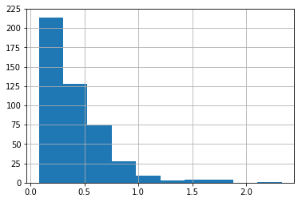

```python
#Plot DiabetesPedigreeFunction Vs Fenales with no diabetes

Pima_diabetes4.loc[Pima_diabetes4['Outcome'] == 0, 'DiabetesPedigreeFunction'].hist()
```

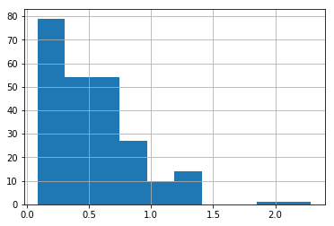

```python
#Plot DiabetesPedigreeFunction Vs Fenales with diabetes

Pima_diabetes4.loc[Pima_diabetes4['Outcome'] == 1, 'DiabetesPedigreeFunction'].hist()
```

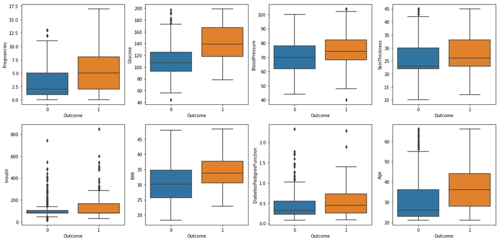

```python
#Plot Boxplot of all features to understand the distribution and Outliers

Pima_diabetes5 = Pima_diabetes4.drop(['index','Ages'],axis=1)
plt.figure(figsize=(20,20))

for column_index, column in enumerate(Pima_diabetes5.columns):
    if column == 'Outcome':
        continue
    plt.subplot(4, 4, column_index + 1)
    sns.boxplot(x='Outcome', y=column, data=Pima_diabetes5)
```

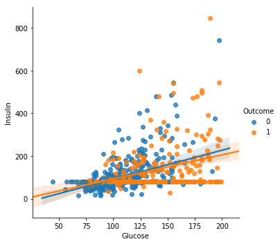

```python
#Plot Insulin Vs Glucose

sns.lmplot(x = "Glucose",  y = "Insulin", data = BP_data, hue = "Outcome")

#Females with diabetes are having high Glucose levels and also, high insulin levels
#but large number of records has insulin=0 and we replaced it with mean value
```

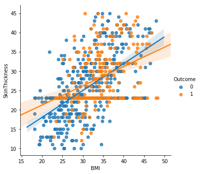

```python
#Plot BMI Vs SkinThickness
sns.lmplot(x = "BMI",  y = "SkinThickness", data = BP_data, hue = "Outcome")
```

```python
#Above plot shows that large portion of females with diabetes are having
# BMI >30 and skinthickness >25.
```